# Présentation sigr2021

01/07/2021

## Champ de recherche

Depuis 2016, appui à la recherche dans différentes disciplines (géomorphologie, géographie, paléoenvironnement, biologie…)

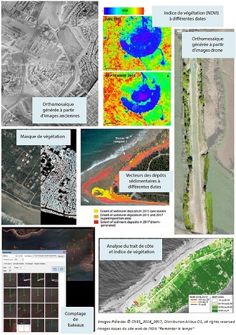

## Outils mobilisés

see https://lienss.univ-larochelle.fr/Acces-aux-outils

- pour la **télédétection**: ENVI, Orfeo ToolBox (libre), eCognition, ArcGis, extension DSAS, Google Earth Engine
- pour la **photogrammétrie**: Pix4Dmapper, Agisoft Metashape, MicMac (libre)
- pour visualiser les **nuages de points**: CloudCompare (libre)
- pour la **cartographie**: ArcGis, Adobe illustrator

## Champ de recherche / reproductivité

- travaux dirigés avec des outils libres/données/code
- documents d’aide (forum MicMac, site web du laboratoire)
- publications avec la méthodologie et les codes python
- suivi d’une stagiaire (Chumil Morales) qui a mis en place un script R pour l’étude d’herbiers sur la baie d’Yves par traitement d’images du satellite Sentinel S2A

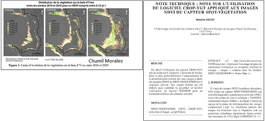

## Reproductivité avec R

- pour réaliser des chaines de traitements simples et facilement transférables en télédétection
- pour fournir un script simple pour réaliser les tâches après la création des modèles numériques de surface (évaluation de l’erreur verticale et statistiques)
- pour faire fonctionner le script R de mon ancienne stagiaire afin de le partager